# Quiz 230412

coop711

2023-04-12

## Red, Black을 잘못 표시한 사람들

| 학번 | 랜덤화출석부 | 구글예습퀴즈 |
| --- | --- | --- |
| 20182946 | Red | Black |
| 20183716 | Red | Black |
| 20183802 | Red | Black |
| 20194108 | Red | Black |
| 20201506 | Black | Red |
| 20203007 | Black | Red |
| 20203041 | Red | Black |
| 20203329 | Red | Black |
| 20213341 | Red | Black |
| 20213929 | Red | Black |
| 20215114 | Red | Black |
| 20221073 | Black | Red |
| 20221523 | Red | Black |
| 20221531 | Black | Red |
| 20222231 | Black | Red |
| 20222413 | Red | Black |
| 20222742 | Red | Black |
| 20224113 | Red | Black |
| 20226646 | Red | Black |
| 20233001 | Red | Black |
| 20233832 | Red | Black |

|  | Red(구글예습퀴즈) | Black(구글예습퀴즈) |
| --- | --- | --- |
| **Red(랜덤화출석부)** | 413 | 16 |
| **Black(랜덤화출석부)** | 5 | 420 |

# 퀴즈 응답 비교

## Q1. 통계학의 기본원리

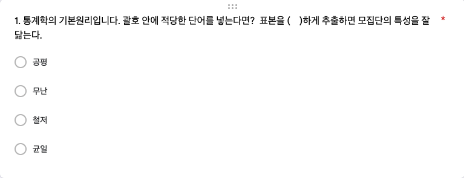

### 공평하게 추출하면 …

|  | 공평 | 무난 | 철저 | 균일 | 계 |
| --- | --- | --- | --- | --- | --- |
| **Red** | 300 | 21 | 7 | 90 | 418 |
| **Black** | 314 | 17 | 8 | 97 | 436 |
| **계** | 614 | 38 | 15 | 187 | 854 |

Pearson’s Chi-squared test with simulated p-value (based on 2000 replicates): `.`

| Test statistic | df | P value |
| --- | --- | --- |
| 0.6899 | NA | 0.8971 |

### 공평하게 추출하면 … (%)

| 공평 | 무난 | 철저 | 균일 | 계 |
| --- | --- | --- | --- | --- |
| 71.9 | 4.4 | 1.8 | 21.9 | 100.0 |

## Q2. 리터러리 다이제스트의 실패

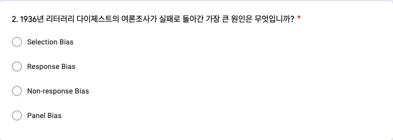

### Selection Bias

|  | Selection Bias | Response Bias | Non-response Bias | Panel Bias | 계 |
| --- | --- | --- | --- | --- | --- |
| **Red** | 272 | 46 | 83 | 17 | 418 |
| **Black** | 268 | 64 | 85 | 19 | 436 |
| **계** | 540 | 110 | 168 | 36 | 854 |

Pearson’s Chi-squared test with simulated p-value (based on 2000 replicates): `.`

| Test statistic | df | P value |
| --- | --- | --- |
| 2.732 | NA | 0.4403 |

### Selection Bias (%)

| Selection Bias | Response Bias | Non-response Bias | Panel Bias | 계 |
| --- | --- | --- | --- | --- |
| 63.2 | 12.9 | 19.7 | 4.2 | 100.0 |

## Q3. 1948년, 여론조사가 듀이를 당선시킨 해

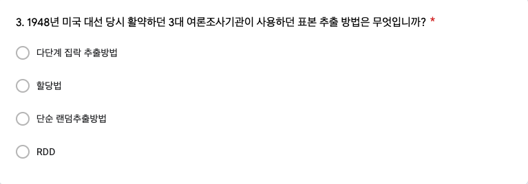

### 할당법의 문제점

|  | 다단계 집락 추출방법 | 할당법 | 단순 랜덤추출방법 | RDD | 계 |
| --- | --- | --- | --- | --- | --- |
| **Red** | 52 | 264 | 84 | 18 | 418 |
| **Black** | 46 | 280 | 90 | 20 | 436 |
| **계** | 98 | 544 | 174 | 38 | 854 |

Pearson’s Chi-squared test with simulated p-value (based on 2000 replicates): `.`

| Test statistic | df | P value |
| --- | --- | --- |
| 0.771 | NA | 0.8676 |

### 할당법의 문제점(%)

| 다단계 집락 추출방법 | 할당법 | 단순 랜덤추출방법 | RDD | 계 |
| --- | --- | --- | --- | --- |
| 11.5 | 63.7 | 20.4 | 4.4 | 100.0 |

## Q4. 1948 미 대선 이후

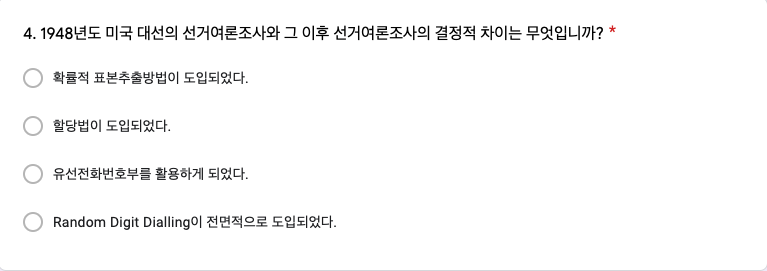

### 확률적 표본추출방법 도입

|  | 확률적 표본추출 | 할당법 | 유선전화번호부 | RDD도입 | 계 |
| --- | --- | --- | --- | --- | --- |
| **Red** | 280 | 62 | 39 | 37 | 418 |
| **Black** | 282 | 58 | 53 | 43 | 436 |
| **계** | 562 | 120 | 92 | 80 | 854 |

Pearson’s Chi-squared test with simulated p-value (based on 2000 replicates): `.`

| Test statistic | df | P value |
| --- | --- | --- |
| 2.343 | NA | 0.4953 |

### 확률적 표본추출방법 도입 … (%)

| 확률적 표본추출 | 할당법 | 유선전화번호부 | RDD도입 | 계 |
| --- | --- | --- | --- | --- |
| 65.8 | 14.1 | 10.8 | 9.4 | 100.0 |

## Q5. 표본오차를 반으로 줄이려면?

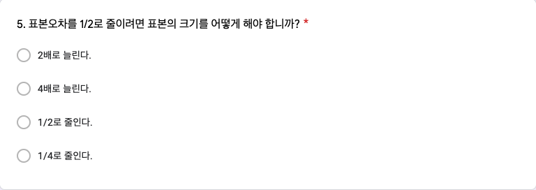

### 4배로 늘려야

|  | 2배로 | 4배로 | 1/2로 | 1/4로 | 계 |
| --- | --- | --- | --- | --- | --- |
| **Red** | 99 | 267 | 36 | 16 | 418 |
| **Black** | 105 | 274 | 38 | 19 | 436 |
| **계** | 204 | 541 | 74 | 35 | 854 |

Pearson’s Chi-squared test with simulated p-value (based on 2000 replicates): `.`

| Test statistic | df | P value |
| --- | --- | --- |
| 0.1989 | NA | 0.9765 |

### 4배로 눌려야 (%)

| 2배로 | 4배로 | 1/2로 | 1/4로 | 계 |
| --- | --- | --- | --- | --- |
| 23.9 | 63.3 | 8.7 | 4.1 | 100.0 |

## Q6. 대선 여론조사의 목표모집단?

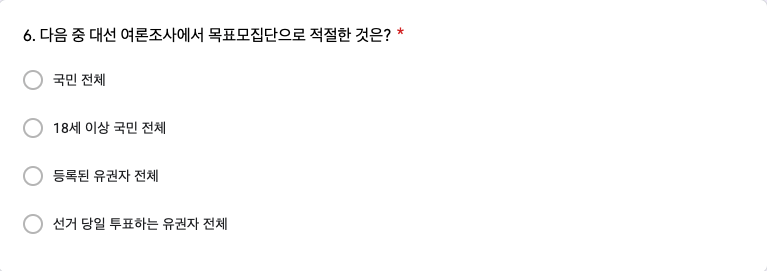

### 선거당일 투표하는 유권자 전체

|  | 국민 전체 | 18세 이상 국민 전체 | 등록된 유권자 전체 | 선거 당일 투표하는 유권자 전체 | 계 |
| --- | --- | --- | --- | --- | --- |
| **Red** | 25 | 97 | 55 | 241 | 418 |
| **Black** | 21 | 123 | 65 | 227 | 436 |
| **계** | 46 | 220 | 120 | 468 | 854 |

Pearson’s Chi-squared test with simulated p-value (based on 2000 replicates): `.`

| Test statistic | df | P value |
| --- | --- | --- |
| 4.295 | NA | 0.2349 |

### 선거당일 투표하는 유권자 전체(%)

| 국민 전체 | 18세 이상 국민 전체 | 등록된 유권자 전체 | 선거 당일 투표하는 유권자 전체 | 계 |
| --- | --- | --- | --- | --- |
| 5.4 | 25.8 | 14.1 | 54.8 | 100.0 |

# Wason Selection

## 추상적 표현과 구체적 표현?

같은 내용의 문제를 추상적으로 물어볼 때와 구체적으로 사례를 들어서 물어볼 때의 정답률에 큰 차이가 있음에 유의. Red 집단에게는 추상적 질문을 먼저 던지고, 구체적 사례를 든 질문을 나중에 던졌으며 Black 집단에게는 구체적 사례를 든 질문을 먼저 던지고, 추상적 질문을 나중에 던졌다. 추상적인 질문에 대해서는 매우 낮은 정답률을 보이지만 구체적인 질문에 대해서는 정답률이 훨씬 올라가는 것을 관찰할 수 있다. 추상적인 질문에 쩔쩔매는 것이 정상이다.

## Q7. Red에 추상적 문제, Black에 구체적 문제

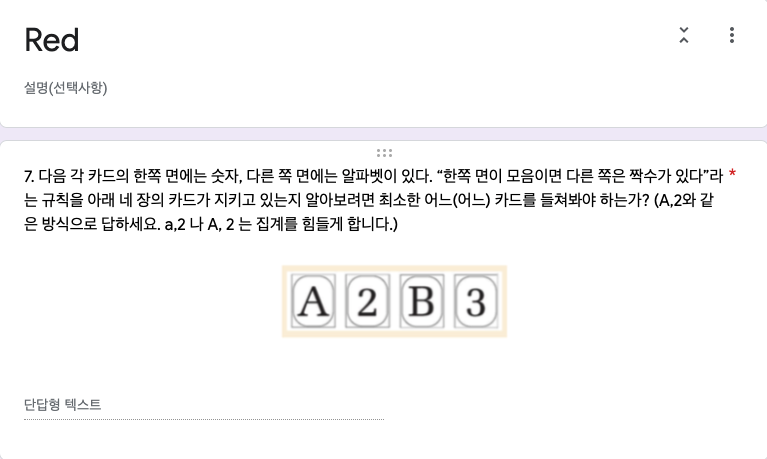

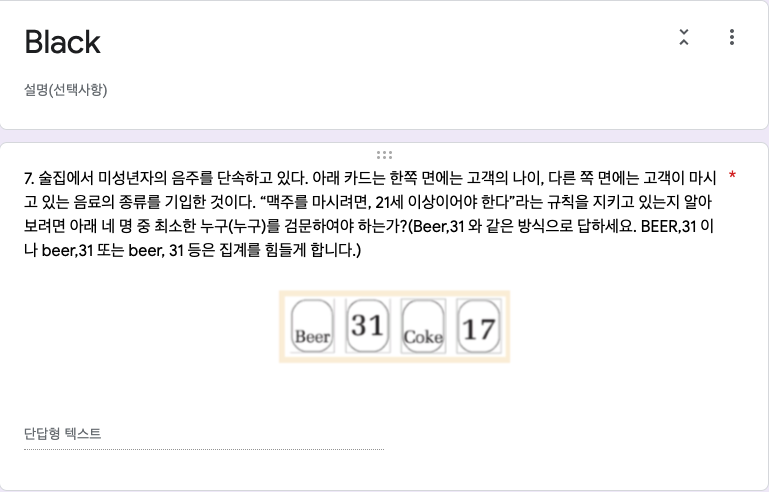

### 집계

Wason Selection 1 in Red

|  | 정답 | 오답 | 계 |
| --- | --- | --- | --- |
| **Red(추상적 질문)** | 87 | 331 | 418 |
| **Black(구체적 질문)** | 232 | 204 | 436 |
| **계** | 319 | 535 | 854 |

### % 비교

|  | 정답 | 오답 | 계 |
| --- | --- | --- | --- |
| **Red(추상적 질문)** | 20.8 | 79.2 | 100.0 |
| **Black(구체적 질문)** | 53.2 | 46.8 | 100.0 |

### Mosaic Plot

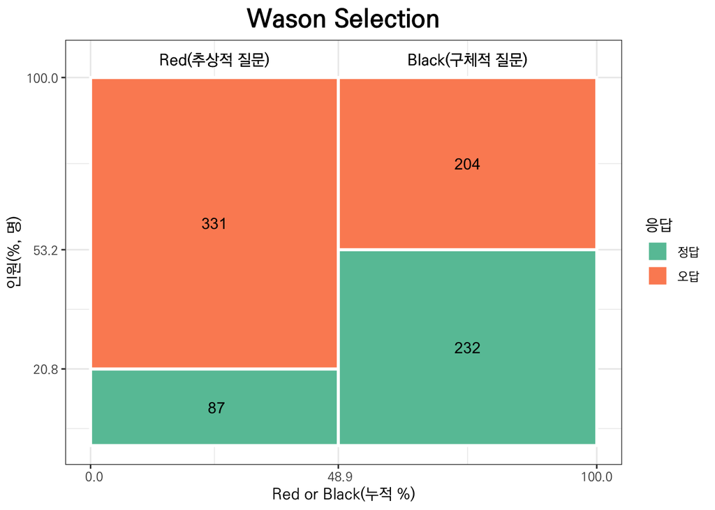

## Q8. Red에 구체적 문제, Black에 추상적 문제

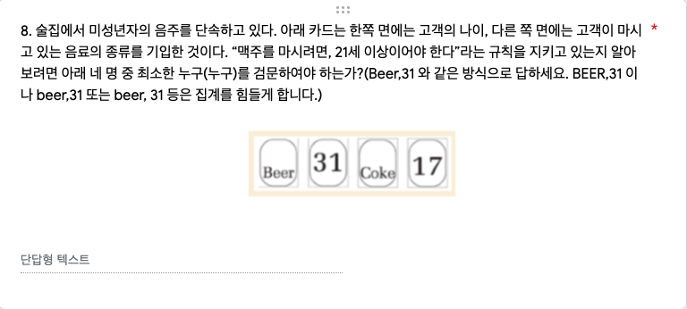

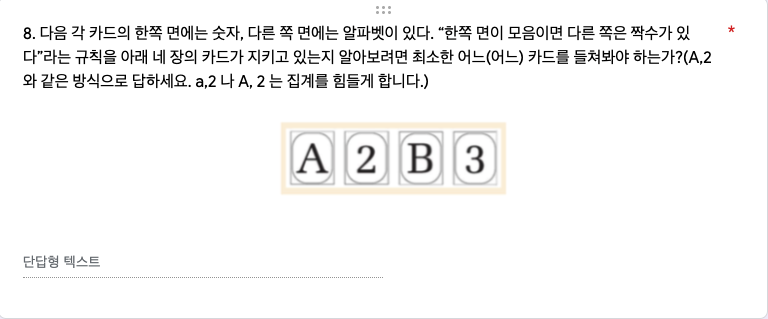

### 집계

Wason Selection 1 in Black

|  | 정답 | 오답 | 계 |
| --- | --- | --- | --- |
| **Red(구체적 질문)** | 198 | 220 | 418 |
| **Black(추상적 질문)** | 52 | 384 | 436 |
| **계** | 250 | 604 | 854 |

### % 비교.

|  | 정답 | 오답 | 계 |
| --- | --- | --- | --- |
| **Red(구체적 질문)** | 47.4 | 52.6 | 100.0 |
| **Black(추상적 질문)** | 11.9 | 88.1 | 100.0 |

### Mosaic Plot

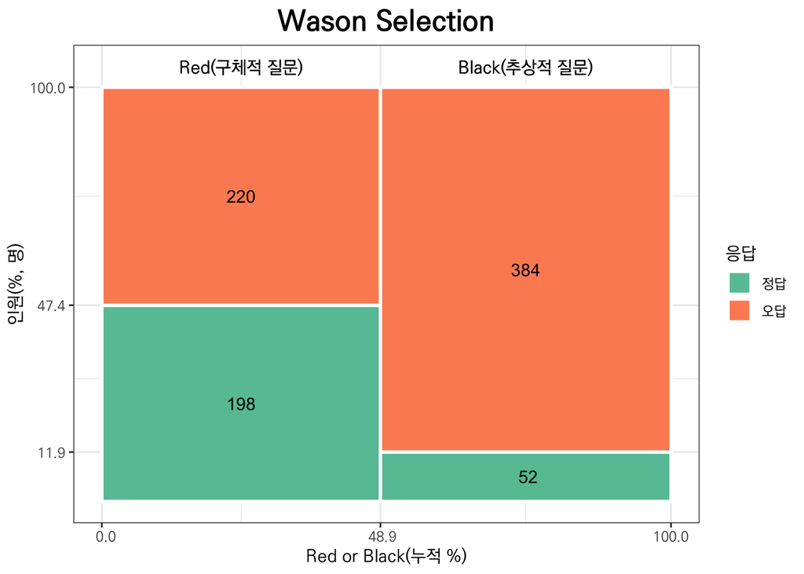

## 학습 순서의 영향

### 집계표

구체적 질문을 먼저 학습하고 추상적 질문을 학습하는 것과 추상적 질문을 먼저 학습하고 구체적 질문을 학습하는 방식 중에 어느 것이 더 나은지 비교한 결과 정답 인원은 매우 닮았는데, 순서에 따라 정답인원의 차이에는 통계적으로 매우 유의한 차이가 관찰되었습니다. 어떻게 해석할 수 있을까요?

Wason Selection

|  | 추상적 질문 정답 | 구체적 질문 정답 | 계 |
| --- | --- | --- | --- |
| **Red(추상적 질문 먼저)** | 87 | 198 | 285 |
| **Black(구체적 질문 먼저)** | 52 | 232 | 284 |

Pearson’s Chi-squared test with Yates’ continuity correction: `.`

| Test statistic | df | P value |
| --- | --- | --- |
| 10.85 | 1 | 0.0009894 * * * |

### % 비교

이 표는 추상적 질문에 대한 Red, Black 간 정답률 차이와 구체적 질문에 대한 Red, Black 간 정답률 차이를 비교하는 것입니다. 1번효과라기 보다는 학습 순서가 정답률에 영향을 미치는 지 알아보려는 것인데, 관찰된 숫자 상으로 보면 추상적 질문 먼저 던졌을 때 정답 비율이 높게 나타나고 그 차이가 통계적으로 매우 유의하기 때문에 추상적 질문을 먼저 던지는 게 더 학습효과가 높다고 할 수 있다고 할 수 있겠습니다.

Wason Selection

|  | 추상적 질문 정답 | 구체적 질문 정답 |
| --- | --- | --- |
| **Red(추상적 질문 먼저)** | 62.6 | 46.0 |
| **Black(구체적 질문 먼저)** | 37.4 | 54.0 |
| **계** | 100.0 | 100.0 |

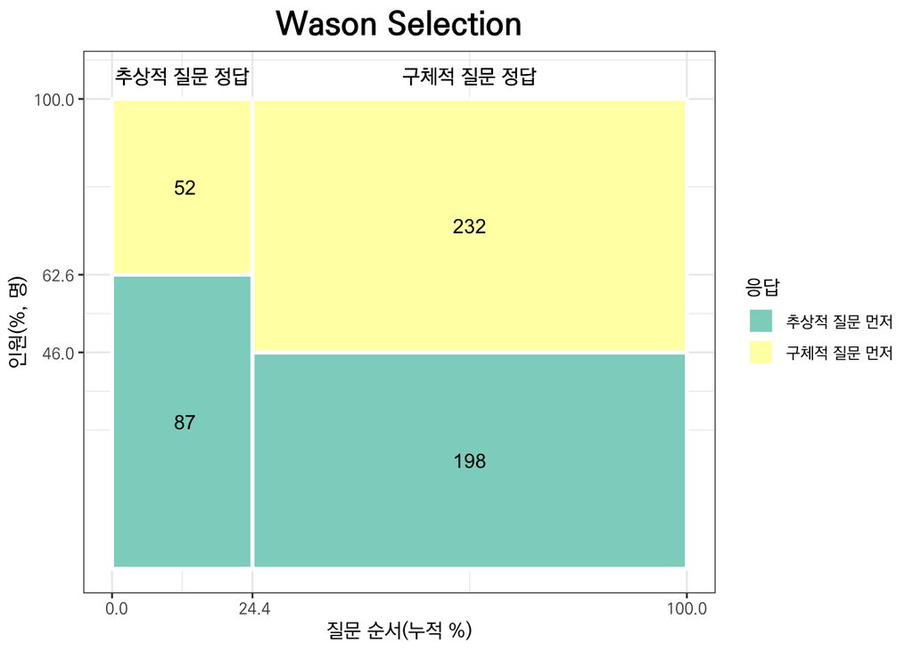

## 합산

### 집계표

|  | 정답 | 오답 | 계 |
| --- | --- | --- | --- |
| **추상적 문제** | 139 | 715 | 854 |
| **구체적 문제** | 430 | 424 | 854 |

### % 비교

|  | 정답 | 오답 | 계 |
| --- | --- | --- | --- |
| **추상적 문제** | 16.3 | 83.7 | 100.0 |
| **구체적 문제** | 50.4 | 49.6 | 100.0 |

### Barplot

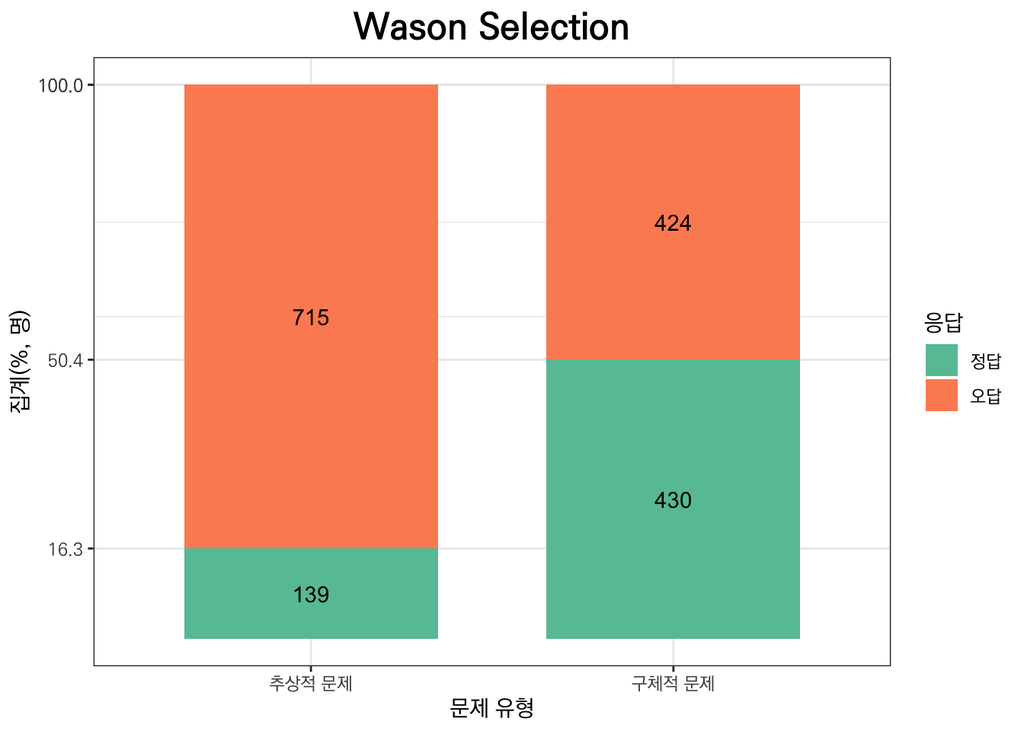

### 일 단위 마감 시간으로부터 제출 시간의 분포

일 단위

|  | [0,1] | (1,2] | (2,3] | (3,4] | (4,5] | (5,6] | (6,7] | (7,8] | (8,9] | (9,10] | (10,11] | (11,12] | (12,13] | (13,14] |
| --- | --- | --- | --- | --- | --- | --- | --- | --- | --- | --- | --- | --- | --- | --- |
| **Red** | 156 | 28 | 29 | 14 | 11 | 7 | 5 | 32 | 21 | 19 | 23 | 22 | 20 | 31 |
| **Black** | 168 | 39 | 14 | 11 | 11 | 8 | 7 | 28 | 19 | 22 | 21 | 22 | 24 | 42 |

Pearson’s Chi-squared test: `.`

| Test statistic | df | P value |
| --- | --- | --- |
| 10.57 | 13 | 0.6471 |

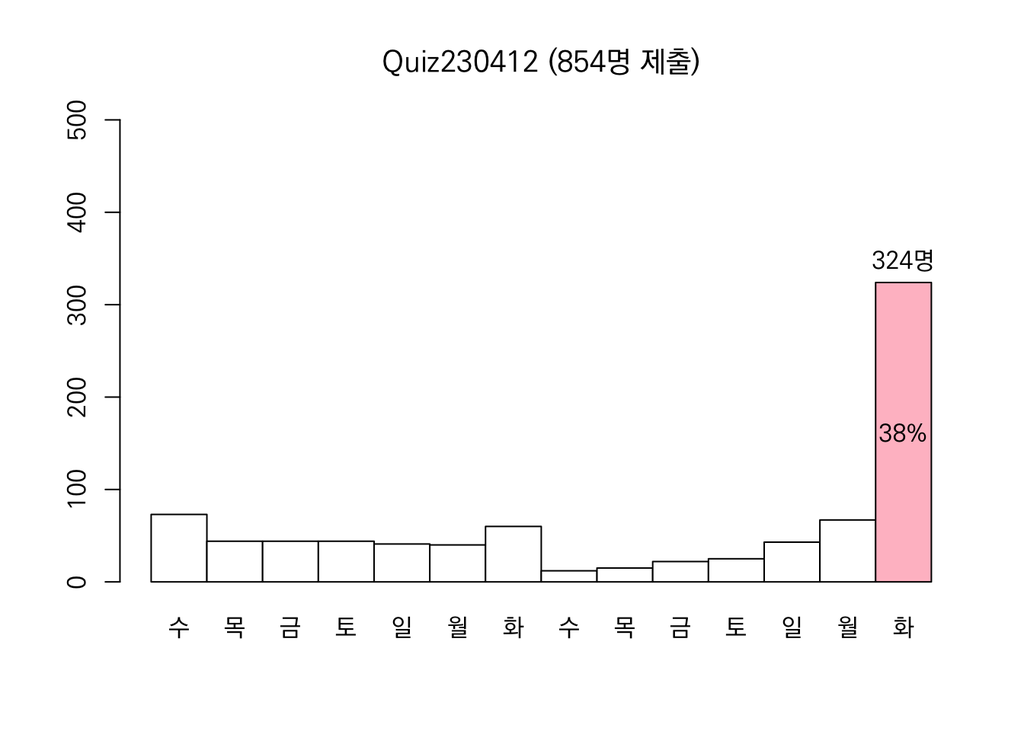